# Reproducible Research: Peer Assessment 1

## Loading and preprocessing the data

Reading the data and sum of steps per day:

```r
activity<- read.csv ("activity.csv")
dailyActivity<- aggregate(steps ~ date, data=activity, sum)
```

Histogram of the daily number of steps:

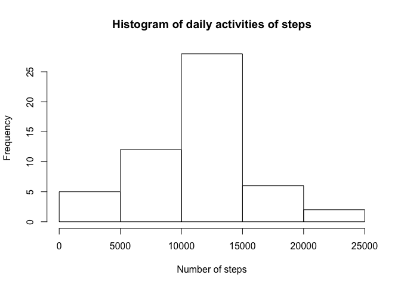

```r
hist(dailyActivity$steps, main="Histogram of daily activities of steps", ylab="Frequency", xlab="Number of steps")
```

## What is mean total number of steps taken per day?

Here is the mean and median of the total number of steps:

```r
mean(dailyActivity$steps)
```

```
## [1] 10766
```

```r
median(dailyActivity$steps)
```

```
## [1] 10765
```

## What is the average daily activity pattern?

Here is the average daily activity pattern:

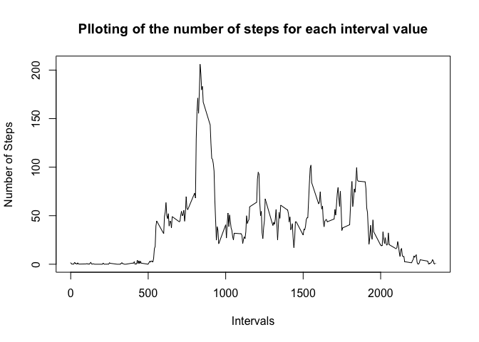

```r
meanIntervals<- aggregate(steps ~ interval, data=activity, mean)
plot(meanIntervals$steps ~ meanIntervals$interval, type="l", main="Plloting of the number of steps for each interval value", xlab="Intervals", ylab="Number of Steps")
```

The Interval number that has the maximum value of steps is 8:35

```r
answer<-subset(meanIntervals, meanIntervals$steps==max(meanIntervals$steps))
answer
```

```
##     interval steps
## 104      835 206.2
```

The number of NA values in steps is 2304

```r
sum(is.na(activity$steps))
```

```
## [1] 2304
```

## Imputing missing values

```r
activity2<- activity
#activity2$steps[is.na(activity2$steps)]<- mean(activity2$steps)
activity2$steps[is.na(activity2$steps)]<- 100
```

Histogram of the daily number of steps for activity2:

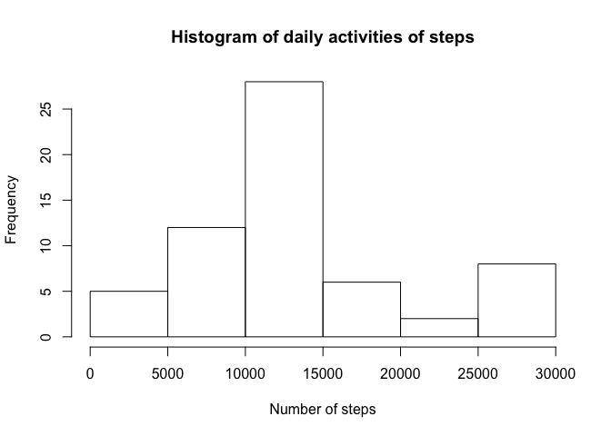

```r
dailyActivity2<- aggregate(steps ~ date, data=activity2, sum)
hist(dailyActivity2$steps, main="Histogram of daily activities of steps", ylab="Frequency", xlab="Number of steps")
```

Here is the mean and median of the total number of steps for activity2:

```r
mean(dailyActivity2$steps)
```

```
## [1] 13131
```

```r
median(dailyActivity2$steps)
```

```
## [1] 11458
```

### The new valuse that are replaced in space of NA values made some difference in the results

It expands the sum of steps then expands the scale of x axis Also, it increases the value of mean and median

## Are there differences in activity patterns between weekdays and weekends?

- Classifing the data into weekdays and weekends and do the steps again.
- Creating a new factor level that has two different values “weekday” and “weekend”

```r
activity$interval <- as.factor(as.character(activity$interval))
intervalMean <- as.numeric(tapply(activity$steps, activity$interval, mean, na.rm = TRUE))
intervals <- data.frame(intervals = as.numeric(levels(activity$interval)), intervalMean)

activity2$day<- c("weekday", "weekday", "weekday", "weekday", "weekday", "weekend", "weekend") [as.POSIXlt(activity2$date)$wday + 1]
weekday <- activity2[activity2$day=="weekday", ]
weekend <- activity2[activity2$day=="weekend", ]
weekdayMean <- as.numeric(tapply(weekday$steps, weekday$interval, mean))
weekendMean <- as.numeric(tapply(weekend$steps, weekend$interval, mean))

intervalsDays <- data.frame(intervals = as.numeric(levels(activity$interval)), weekdayMean, weekendMean)
intervalsDays <- intervalsDays[order(intervalsDays$intervals), ]
```

Preparing the plotting factors and do the plot function two times:

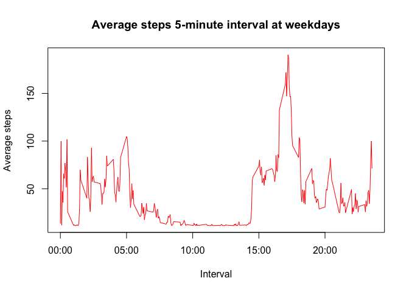

```r
labels <- c("00:00", "05:00", "10:00", "15:00", "20:00")
labels.at <- seq(0, 2000, 500)

plot(intervalsDays$intervals, intervalsDays$weekdayMean, type = "l", col = "red", ylab = "Average steps", xlab = "Interval", main = "Average steps 5-minute interval at weekdays", xaxt = "n")
axis(side = 1, at = labels.at, labels = labels)
```

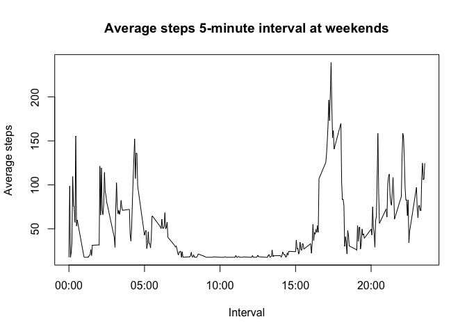

```r
plot(intervalsDays$intervals, intervalsDays$weekendMean, type = "l", ylab = "Average steps", xlab = "Interval", main = "Average steps 5-minute interval at weekends", xaxt = "n")
axis(side = 1, at = labels.at, labels = labels)
```

Here is the end of the report…